DATASET ACTIVATE DataSet3.  
DATASET ACTIVATE DataSet3.  
SAVE OUTFILE='Z:\Documents\GitHub\STISIM-Task-Analysis\SPSS Results\Saccade_peakV_30-40.sav'  
/COMPRESSED.  
DATASET ACTIVATE DataSet4.  
DATASET CLOSE DataSet3.  
GET  
FILE='Z:\Documents\GitHub\STISIM-Task-Analysis\SPSS Results\Saccade_meanV_20-30.sav'.  
DATASET NAME DataSet5 WINDOW=FRONT.  
* Encoding: UTF-8.  
EXAMINE VARIABLES=S1_R1 S1_R2 S2_R1 S2_R2  
/PLOT BOXPLOT NPPLOT  
/COMPARE GROUPS  
/STATISTICS NONE  
/CINTERVAL 95  
/MISSING LISTWISE  
/NOTOTAL.

# **Explore**

NotesNotes, table, 0 levels of column headers and 2 levels of row headers, table with 3 columns and 14 rows

| Output Created |  | 16-APR-2019 00:52:44 |
| --- | --- | --- |
| Comments |  |  |
| Input | Data | Z:\Documents\GitHub\STISIM-Task-Analysis\SPSS Results\Saccade_meanV_20-30.sav |
|  | Active Dataset | DataSet5 |
|  | Filter | <none> |
|  | Weight | <none> |
|  | Split File | <none> |
|  | N of Rows in Working Data File | 13 |
| Missing Value Handling | Definition of Missing | User-defined missing values for dependent variables are treated as missing. |
|  | Cases Used | Statistics are based on cases with no missing values for any dependent variable or factor used. |
| Syntax |  | EXAMINE VARIABLES=S1_R1 S1_R2 S2_R1 S2_R2 /PLOT BOXPLOT NPPLOT /COMPARE GROUPS /STATISTICS NONE /CINTERVAL 95 /MISSING LISTWISE /NOTOTAL. |
| Resources | Processor Time | 00:00:02.33 |
|  | Elapsed Time | 00:00:02.20 |

[DataSet5] Z:\Documents\GitHub\STISIM-Task-Analysis\SPSS Results\Saccade_meanV_20-30.sav

Case Processing SummaryCase Processing Summary, table, 3 levels of column headers and 1 levels of row headers, table with 7 columns and 8 rows

|  | Cases |  |  |  |  |  |
| --- | --- | --- | --- | --- | --- | --- |
|  | Valid |  | Missing |  | Total |  |
|  | N | Percent | N | Percent | N | Percent |
| S1_R1 | 9 | 69.2% | 4 | 30.8% | 13 | 100.0% |
| S1_R2 | 9 | 69.2% | 4 | 30.8% | 13 | 100.0% |
| S2_R1 | 9 | 69.2% | 4 | 30.8% | 13 | 100.0% |
| S2_R2 | 9 | 69.2% | 4 | 30.8% | 13 | 100.0% |

Tests of NormalityTests of Normality, table, 2 levels of column headers and 1 levels of row headers, table with 7 columns and 9 rows

|  | Kolmogorov-Smirnov<sup>a</sup> |  |  | Shapiro-Wilk |  |  |
| --- | --- | --- | --- | --- | --- | --- |
|  | Statistic | df | Sig. | Statistic | df | Sig. |
| S1_R1 | .225 | 9 | .200* | .916 | 9 | .357 |
| S1_R2 | .177 | 9 | .200* | .974 | 9 | .924 |
| S2_R1 | .174 | 9 | .200* | .876 | 9 | .143 |
| S2_R2 | .119 | 9 | .200* | .985 | 9 | .983 |

*. This is a lower bound of the true significance.  
a. Lilliefors Significance Correction

# **S1_R1**

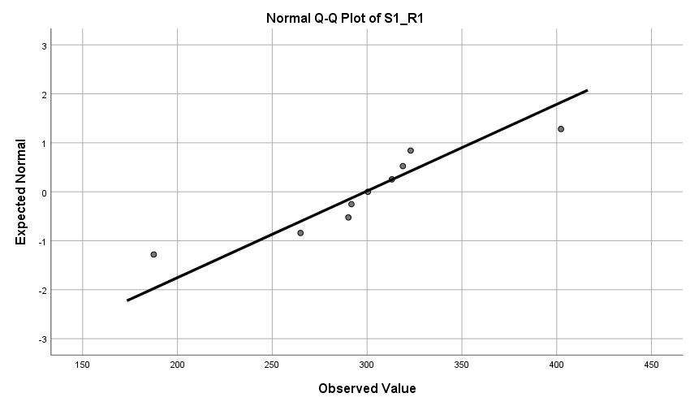

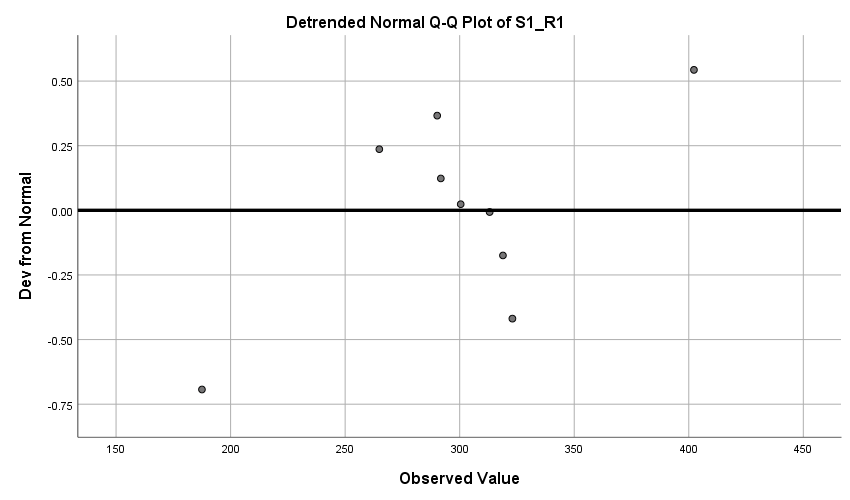

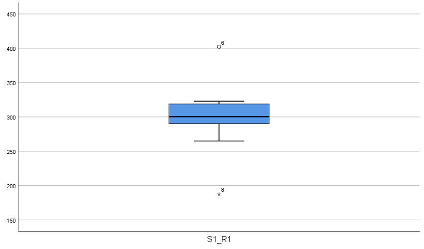

# **S1_R2**

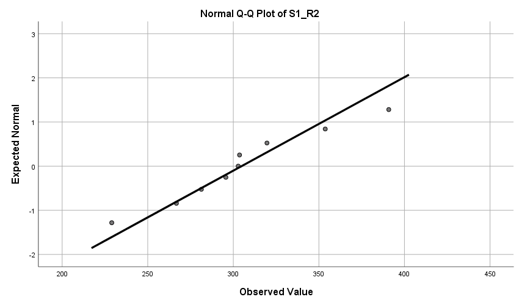

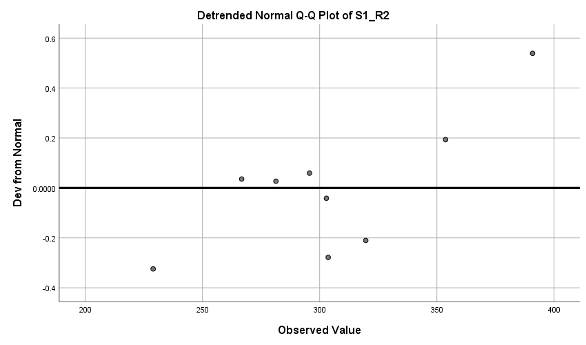

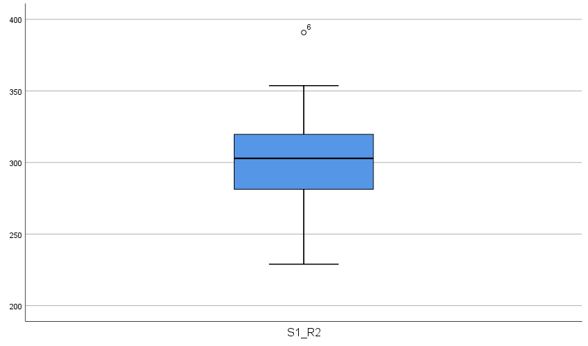

# **S2_R1**

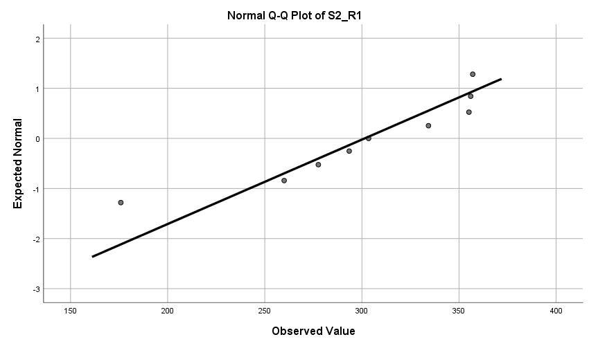

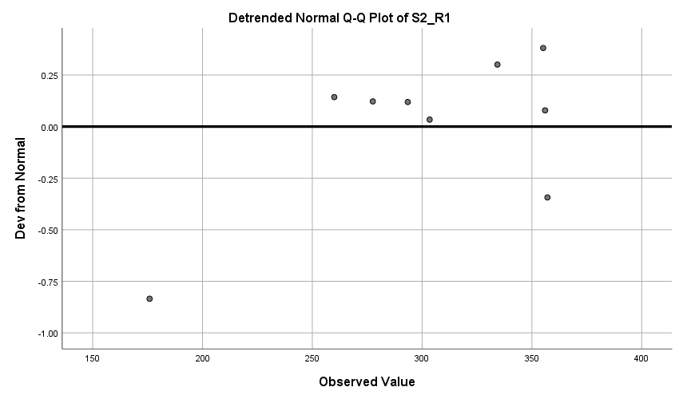

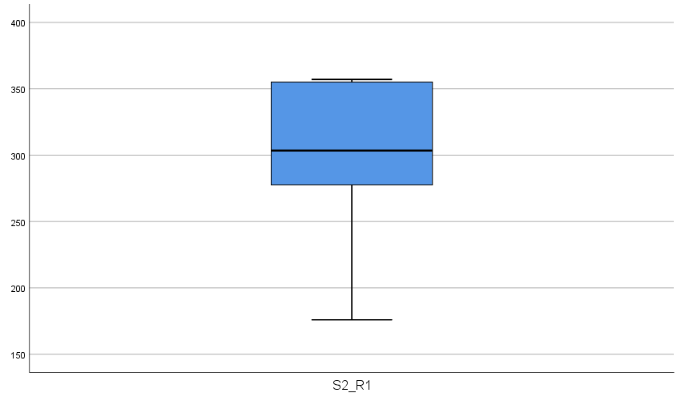

# **S2_R2**

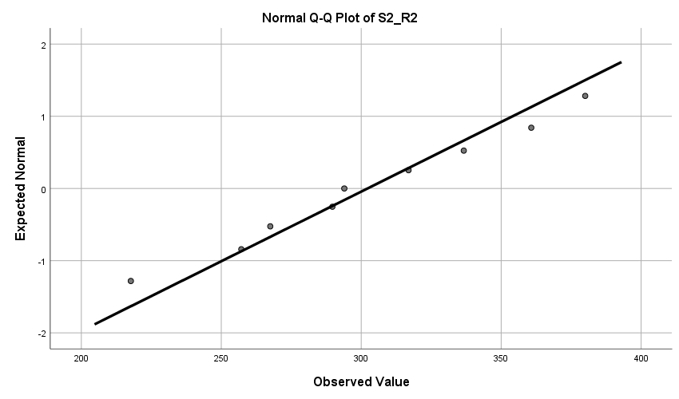

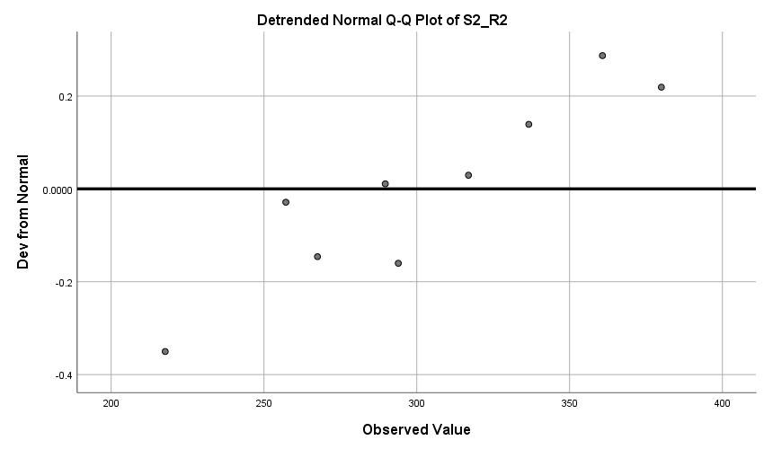

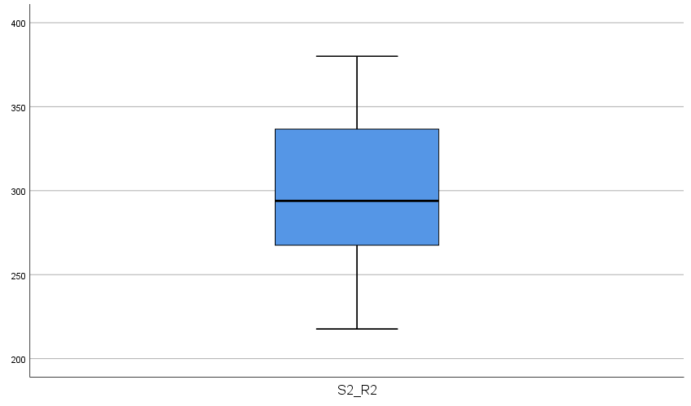

T-TEST PAIRS=S1_R1 S2_R1 S1_R2 WITH S1_R2 S2_R2 S2_R2 (PAIRED)  
/CRITERIA=CI(.9500)  
/MISSING=ANALYSIS.

# **T-Test**

NotesNotes, table, 0 levels of column headers and 2 levels of row headers, table with 3 columns and 14 rows

| Output Created |  | 16-APR-2019 00:52:46 |
| --- | --- | --- |
| Comments |  |  |
| Input | Data | Z:\Documents\GitHub\STISIM-Task-Analysis\SPSS Results\Saccade_meanV_20-30.sav |
|  | Active Dataset | DataSet5 |
|  | Filter | <none> |
|  | Weight | <none> |
|  | Split File | <none> |
|  | N of Rows in Working Data File | 13 |
| Missing Value Handling | Definition of Missing | User defined missing values are treated as missing. |
|  | Cases Used | Statistics for each analysis are based on the cases with no missing or out-of-range data for any variable in the analysis. |
| Syntax |  | T-TEST PAIRS=S1_R1 S2_R1 S1_R2 WITH S1_R2 S2_R2 S2_R2 (PAIRED) /CRITERIA=CI(.9500) /MISSING=ANALYSIS. |
| Resources | Processor Time | 00:00:00.00 |
|  | Elapsed Time | 00:00:00.43 |

Paired Samples StatisticsPaired Samples Statistics, table, 1 levels of column headers and 2 levels of row headers, table with 6 columns and 8 rows

|  |  | Mean | N | Std. Deviation | Std. Error Mean |
| --- | --- | --- | --- | --- | --- |
| Pair 1 | S1_R1 | 299.088182 | 11 | 52.5338770 | 15.8395599 |
|  | S1_R2 | 305.399091 | 11 | 43.0879910 | 12.9915181 |
| Pair 2 | S2_R1 | 300.565455 | 11 | 57.1779651 | 17.2398051 |
|  | S2_R2 | 298.741818 | 11 | 51.3145036 | 15.4719050 |
| Pair 3 | S1_R2 | 305.869091 | 11 | 56.2069482 | 16.9470325 |
|  | S2_R2 | 298.741818 | 11 | 51.3145036 | 15.4719050 |

Paired Samples CorrelationsPaired Samples Correlations, table, 1 levels of column headers and 2 levels of row headers, table with 5 columns and 5 rows

|  |  | N | Correlation | Sig. |
| --- | --- | --- | --- | --- |
| Pair 1 | S1_R1 & S1_R2 | 11 | .947 | .000 |
| Pair 2 | S2_R1 & S2_R2 | 11 | .884 | .000 |
| Pair 3 | S1_R2 & S2_R2 | 11 | .909 | .000 |

Paired Samples TestPaired Samples Test, table, 3 levels of column headers and 2 levels of row headers, table with 10 columns and 7 rows

|  |  | Paired Differences |  |  |  |  | t | df | Sig. (2-tailed) |  |  |  |
| --- | --- | --- | --- | --- | --- | --- | --- | --- | --- | --- | --- | --- |
|  |  | Mean | Std. Deviation | Std. Error Mean | 95% Confidence Interval of the Difference |  |  |  |  |  |  |  |
|  |  |  |  |  | Lower | Upper |  |  |  |  |  |  |
| Pair 1 | S1_R1 - S1_R2 | -6.3109091 | 18.0991721 | 5.4571057 | -18.4700983 | 5.8482801 |  |  |  | -1.156 | 10 | .274 |
| Pair 2 | S2_R1 - S2_R2 | 1.8236364 | 26.7050873 | 8.0518868 | -16.1170854 | 19.7643581 |  |  |  | .226 | 10 | .825 |
| Pair 3 | S1_R2 - S2_R2 | 7.1272727 | 23.4525560 | 7.0712117 | -8.6283688 | 22.8829142 | 1.008 | 10 | .337 |  |  |  |

COMPUTE logS1_R1=LG10(S1_R1).  
EXECUTE.  
COMPUTE logS1_R2=LG10(S1_R2).  
EXECUTE.  
COMPUTE logS2_R1=LG10(S2_R1).  
EXECUTE.  
COMPUTE logS2_R2=LG10(S2_R2).  
EXECUTE.  
EXAMINE VARIABLES=logS1_R1 logS1_R2 logS2_R1 logS2_R2  
/PLOT NPPLOT  
/STATISTICS NONE  
/CINTERVAL 95  
/MISSING LISTWISE  
/NOTOTAL.

# **Explore**

NotesNotes, table, 0 levels of column headers and 2 levels of row headers, table with 3 columns and 14 rows

| Output Created |  | 16-APR-2019 00:52:47 |
| --- | --- | --- |
| Comments |  |  |
| Input | Data | Z:\Documents\GitHub\STISIM-Task-Analysis\SPSS Results\Saccade_meanV_20-30.sav |
|  | Active Dataset | DataSet5 |
|  | Filter | <none> |
|  | Weight | <none> |
|  | Split File | <none> |
|  | N of Rows in Working Data File | 13 |
| Missing Value Handling | Definition of Missing | User-defined missing values for dependent variables are treated as missing. |
|  | Cases Used | Statistics are based on cases with no missing values for any dependent variable or factor used. |
| Syntax |  | EXAMINE VARIABLES=logS1_R1 logS1_R2 logS2_R1 logS2_R2 /PLOT NPPLOT /STATISTICS NONE /CINTERVAL 95 /MISSING LISTWISE /NOTOTAL. |
| Resources | Processor Time | 00:00:01.52 |
|  | Elapsed Time | 00:00:01.46 |

Case Processing SummaryCase Processing Summary, table, 3 levels of column headers and 1 levels of row headers, table with 7 columns and 8 rows

|  | Cases |  |  |  |  |  |
| --- | --- | --- | --- | --- | --- | --- |
|  | Valid |  | Missing |  | Total |  |
|  | N | Percent | N | Percent | N | Percent |
| logS1_R1 | 9 | 69.2% | 4 | 30.8% | 13 | 100.0% |
| logS1_R2 | 9 | 69.2% | 4 | 30.8% | 13 | 100.0% |
| logS2_R1 | 9 | 69.2% | 4 | 30.8% | 13 | 100.0% |
| logS2_R2 | 9 | 69.2% | 4 | 30.8% | 13 | 100.0% |

Tests of NormalityTests of Normality, table, 2 levels of column headers and 1 levels of row headers, table with 7 columns and 9 rows

|  | Kolmogorov-Smirnov<sup>a</sup> |  |  | Shapiro-Wilk |  |  |
| --- | --- | --- | --- | --- | --- | --- |
|  | Statistic | df | Sig. | Statistic | df | Sig. |
| logS1_R1 | .252 | 9 | .102 | .876 | 9 | .143 |
| logS1_R2 | .149 | 9 | .200* | .980 | 9 | .966 |
| logS2_R1 | .201 | 9 | .200* | .821 | 9 | .035 |
| logS2_R2 | .101 | 9 | .200* | .978 | 9 | .955 |

*. This is a lower bound of the true significance.  
a. Lilliefors Significance Correction

# **logS1_R1**

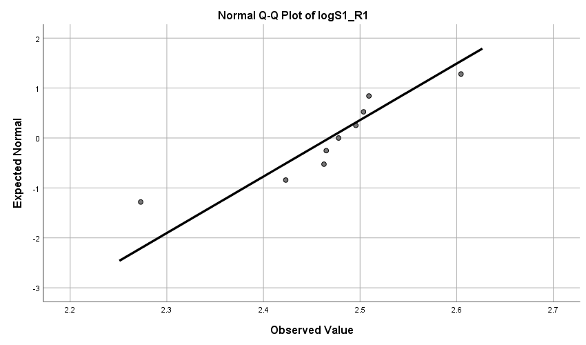

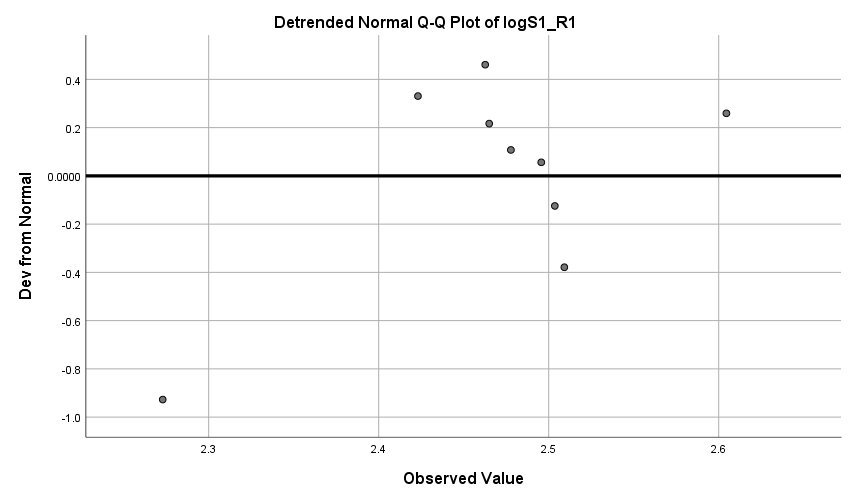

# **logS1_R2**

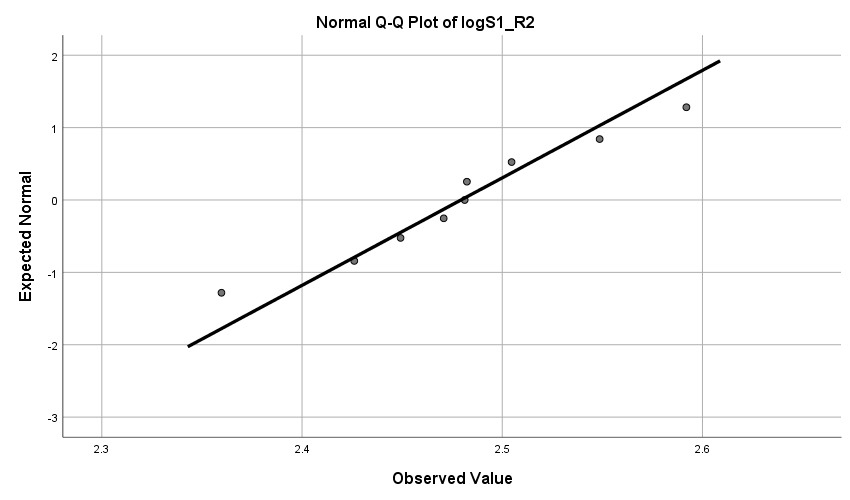

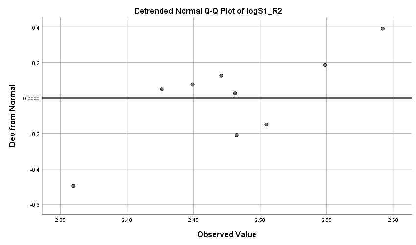

# **logS2_R1**

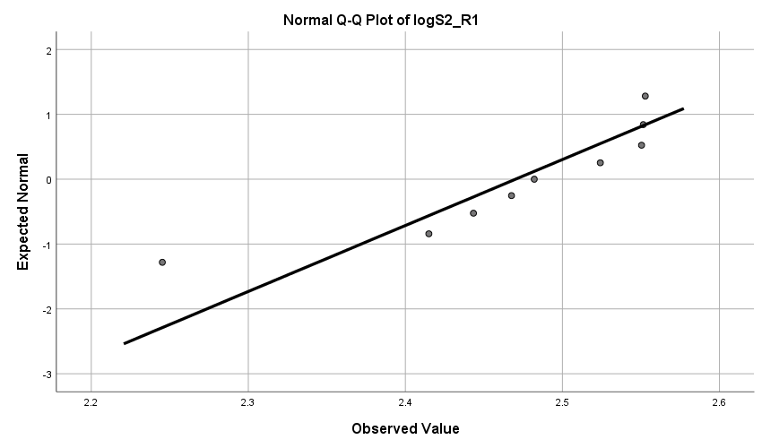

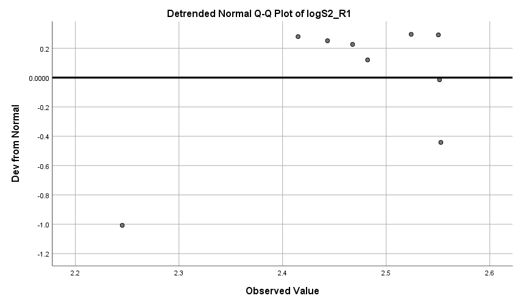

# **logS2_R2**

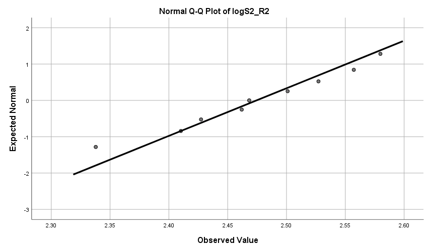

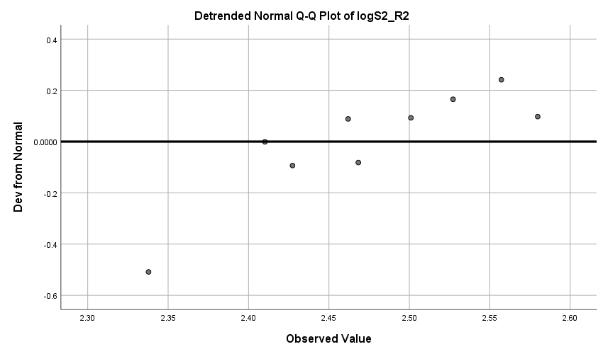

T-TEST PAIRS=logS1_R1 logS2_R1 logS1_R2 WITH logS1_R2 logS2_R2 logS2_R2 (PAIRED)  
/CRITERIA=CI(.9500)  
/MISSING=ANALYSIS.

# **T-Test**

NotesNotes, table, 0 levels of column headers and 2 levels of row headers, table with 3 columns and 14 rows

| Output Created |  | 16-APR-2019 00:52:49 |
| --- | --- | --- |
| Comments |  |  |
| Input | Data | Z:\Documents\GitHub\STISIM-Task-Analysis\SPSS Results\Saccade_meanV_20-30.sav |
|  | Active Dataset | DataSet5 |
|  | Filter | <none> |
|  | Weight | <none> |
|  | Split File | <none> |
|  | N of Rows in Working Data File | 13 |
| Missing Value Handling | Definition of Missing | User defined missing values are treated as missing. |
|  | Cases Used | Statistics for each analysis are based on the cases with no missing or out-of-range data for any variable in the analysis. |
| Syntax |  | T-TEST PAIRS=logS1_R1 logS2_R1 logS1_R2 WITH logS1_R2 logS2_R2 logS2_R2 (PAIRED) /CRITERIA=CI(.9500) /MISSING=ANALYSIS. |
| Resources | Processor Time | 00:00:00.00 |
|  | Elapsed Time | 00:00:00.00 |

Paired Samples StatisticsPaired Samples Statistics, table, 1 levels of column headers and 2 levels of row headers, table with 6 columns and 8 rows

|  |  | Mean | N | Std. Deviation | Std. Error Mean |
| --- | --- | --- | --- | --- | --- |
| Pair 1 | logS1_R1 | 2.4692 | 11 | .08180 | .02466 |
|  | logS1_R2 | 2.4809 | 11 | .06145 | .01853 |
| Pair 2 | logS2_R1 | 2.4696 | 11 | .09334 | .02814 |
|  | logS2_R2 | 2.4693 | 11 | .07625 | .02299 |
| Pair 3 | logS1_R2 | 2.4788 | 11 | .08023 | .02419 |
|  | logS2_R2 | 2.4693 | 11 | .07625 | .02299 |

Paired Samples CorrelationsPaired Samples Correlations, table, 1 levels of column headers and 2 levels of row headers, table with 5 columns and 5 rows

|  |  | N | Correlation | Sig. |
| --- | --- | --- | --- | --- |
| Pair 1 | logS1_R1 & logS1_R2 | 11 | .944 | .000 |
| Pair 2 | logS2_R1 & logS2_R2 | 11 | .884 | .000 |
| Pair 3 | logS1_R2 & logS2_R2 | 11 | .924 | .000 |

Paired Samples TestPaired Samples Test, table, 3 levels of column headers and 2 levels of row headers, table with 10 columns and 7 rows

|  |  | Paired Differences |  |  |  |  | t | df | Sig. (2-tailed) |  |  |  |
| --- | --- | --- | --- | --- | --- | --- | --- | --- | --- | --- | --- | --- |
|  |  | Mean | Std. Deviation | Std. Error Mean | 95% Confidence Interval of the Difference |  |  |  |  |  |  |  |
|  |  |  |  |  | Lower | Upper |  |  |  |  |  |  |
| Pair 1 | logS1_R1 - logS1_R2 | -.01177 | .03128 | .00943 | -.03278 | .00925 |  |  |  | -1.248 | 10 | .241 |
| Pair 2 | logS2_R1 - logS2_R2 | .00026 | .04407 | .01329 | -.02935 | .02987 |  |  |  | .020 | 10 | .985 |
| Pair 3 | logS1_R2 - logS2_R2 | .00953 | .03069 | .00925 | -.01109 | .03014 | 1.030 | 10 | .327 |  |  |  |

*Nonparametric Tests: Related Samples.  
NPAR TESTS  
/WILCOXON=logS1_R1 logS2_R1 logS1_R2 WITH logS1_R2 logS2_R2 logS2_R2 (PAIRED)  
/MISSING ANALYSIS.

# **NPar Tests**

NotesNotes, table, 0 levels of column headers and 2 levels of row headers, table with 3 columns and 16 rows

| Output Created |  | 16-APR-2019 00:52:49 |
| --- | --- | --- |
| Comments |  |  |
| Input | Data | Z:\Documents\GitHub\STISIM-Task-Analysis\SPSS Results\Saccade_meanV_20-30.sav |
|  | Active Dataset | DataSet5 |
|  | Filter | <none> |
|  | Weight | <none> |
|  | Split File | <none> |
|  | N of Rows in Working Data File | 13 |
| Missing Value Handling | Definition of Missing | User-defined missing values are treated as missing. |
|  | Cases Used | Statistics for each test are based on all cases with valid data for the variable(s) used in that test. |
| Syntax |  | NPAR TESTS /WILCOXON=logS1_R1 logS2_R1 logS1_R2 WITH logS1_R2 logS2_R2 logS2_R2 (PAIRED) /MISSING ANALYSIS. |
| Resources | Processor Time | 00:00:00.00 |
|  | Elapsed Time | 00:00:00.01 |
|  | Number of Cases Allowed<sup>a</sup> | 349525 |

a. Based on availability of workspace memory.

# **Wilcoxon Signed Ranks Test**

RanksRanks, table, 1 levels of column headers and 2 levels of row headers, table with 5 columns and 23 rows

|  |  | N | Mean Rank | Sum of Ranks |
| --- | --- | --- | --- | --- |
| logS1_R2 - logS1_R1 | Negative Ranks | 4<sup>a</sup> | 6.00 | 24.00 |
|  | Positive Ranks | 7<sup>b</sup> | 6.00 | 42.00 |
|  | Ties | 0<sup>c</sup> |  |  |
|  | Total | 11 |  |  |
| logS2_R2 - logS2_R1 | Negative Ranks | 6<sup>d</sup> | 5.50 | 33.00 |
|  | Positive Ranks | 5<sup>e</sup> | 6.60 | 33.00 |
|  | Ties | 0<sup>f</sup> |  |  |
|  | Total | 11 |  |  |
| logS2_R2 - logS1_R2 | Negative Ranks | 6<sup>g</sup> | 6.67 | 40.00 |
|  | Positive Ranks | 5<sup>h</sup> | 5.20 | 26.00 |
|  | Ties | 0<sup>i</sup> |  |  |
|  | Total | 11 |  |  |

a. logS1_R2 < logS1_R1  
b. logS1_R2 > logS1_R1  
c. logS1_R2 = logS1_R1  
d. logS2_R2 < logS2_R1  
e. logS2_R2 > logS2_R1  
f. logS2_R2 = logS2_R1  
g. logS2_R2 < logS1_R2  
h. logS2_R2 > logS1_R2  
i. logS2_R2 = logS1_R2

Test Statistics<sup>a</sup>Test Statistics, table, 1 levels of column headers and 1 levels of row headers, table with 4 columns and 8 rows

|  | logS1_R2 - logS1_R1 | logS2_R2 - logS2_R1 | logS2_R2 - logS1_R2 |
| --- | --- | --- | --- |
| Z | -.800<sup>b</sup> | .000<sup>c</sup> | -.622<sup>d</sup> |
| Asymp. Sig. (2-tailed) | .424 | 1.000 | .534 |

a. Wilcoxon Signed Ranks Test  
b. Based on negative ranks.  
c. The sum of negative ranks equals the sum of positive ranks.  
d. Based on positive ranks.